# Simulation-Based Statistics

Module 5

Clemens S. Heithecker

# Setup

In this module we use the tidyverse package to manipulate data frames.

```r
library(tidyverse)
```

# Statistical Testing vs. Simulation

Performing *statistical simulations* to gain statistical insights have become possible with faster computers and better software. Statistically simulating means repeatedly generating artificial data giving a model or assumptions and analyzing the outcomes. These simulations can be an alternative to performing traditional *statistical tests*.

# Probability

Data analysis often involves an element of chance leading to uncertainty when drawing conclusions.

For example, suppose we ask 30 students from the Netherlands to report their height and gender. Their answers are recorded in `height-survey.csv`.

```r
survey <- read.csv("data/height-survey.csv")

survey
```

| height | gender |
| --- | --- |
| 178 | M |
| 167 | F |
| 181 | F |
| 171 | M |
| 187 | M |
| 180 | M |
| 184 | M |
| 181 | F |
| 182 | M |
| 178 | F |

[output cut: 20 more lines]

We want to know if there is a structural difference in heights when comparing female with male students.

Let’s start off by using descriptive statistics to analyze the data.

## Exercise 1—A Histogram

Plot a histogram of all heights in the data set independent of gender.

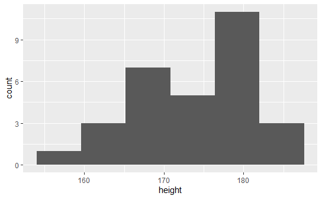

```r
ggplot(data = survey) +
  geom_histogram(mapping = aes(x = height),
                 bins = 6)
```

Then, plot a histogram using `facet_wrap()` for each gender separately.

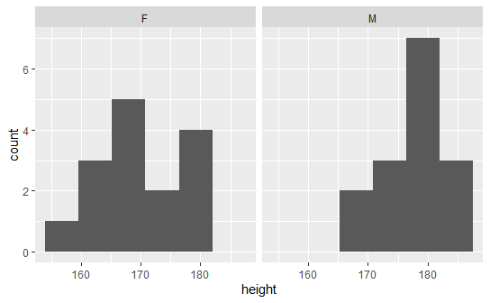

```r
ggplot(data = survey) +
  geom_histogram(mapping = aes(x = height),
                 # The number of bins
                 bins = 6) +
  facet_wrap(~gender)
```

Finally, calculate the mean height by gender group.

```r
survey %>%
  group_by(gender) %>%
  summarise(mean_height = mean(height))
```

| gender | mean_height |
| --- | --- |
| F | 170.4 |
| M | 177.6 |

The data shows that on average female students in the survey data are shorter compared to male students. But to draw a statistical conclusion, we should use a statistical model.

[Wikipedia](https://en.wikipedia.org/wiki/Statistical_model) defines a statistical model as

> […] a mathematical model that embodies a set of statistical assumptions concerning the generation of sample data (and similar data from a larger population). A statistical model represents, often in considerably idealized form, the data-generating process.

For our idealized statistical model we will use a normal distribution.

# The Normal Distribution

For data which is spread out around a central location it is useful to assume that the data follows a normal distribution

The normal distribution is described using two parameters:

- the *central location* (or the *mean*)
- and the amount of *spread* around the central location

The spread of a set of numbers can be calculated by the *standard deviation* (SD).

## Exercise 2—Standard Deviation

Calculate the center location (mean) and the amount of spread in the heights. Use the `sd()` function to calculate the standard deviation.

```r
mean <- mean(survey$height)
sd <- sd(survey$height)

print(c(mean = mean, sd = sd))
```

```
      mean         sd
174.000000   7.629344
```

We can simulate data from a normal distribution using the `rnorm()` function in R.

Let’s simulate a large data set of fake height values. To ensure we obtain the same set of random numbers each time we run the code, we use the `set.seed()` function.

## Exercise 3—Sampling Values from a Normal Distribution

Generate 10,000 values from a normal distribution with mean 181 and a standard deviation of 10. Then, plot a histogram of these numbers.

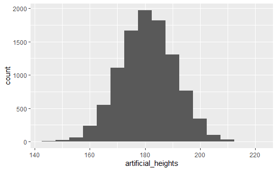

```r
set.seed(2022)

artificial_heights <- rnorm(n = 10000, mean = 181, sd = 10)

ggplot() +
  geom_histogram(mapping = aes(x = artificial_heights),
                 # The width of the bins
                 binwidth = 5)
```

# A Simple Height Model

Let’s make a simple model of heights and compare the simulated data from the model with the observed data from the survey.

For the simple model assume no structural differences in height between female and male students.

We already know that the survey height data has matching characterizes to a the normal distribution. In other words, we observe a central location with symmetric spead and no extreme values.

## Exercise 4—Drawing from a Normal Distribution

Simulate 10 data points from a normal distribution with mean and standard deviation equal to the observed heights. Then, calculate the mean for the generated data points.

```r
set.seed(2022)

simulation <- rnorm(n = 10,
               mean = mean(survey$height),
               sd = sd(survey$height))

mean(simulation)
```

```
[1] 169.6993
```

## Exercise 5—Simulating 10,000 Times

Now write a **for loop** to execute the code from the previous exercise 10,000 times. Store all values of `mean(simulation)` in a vector `mean_siumulation`. With that, we end up with 10,000 mean values, all from different simulation runs, but from the same underlying model. Finally, plot a histogram of the 10,000 means.

[figure not shown]

# Comparing the Model with the Observed Data

## Exercise 6—Adding Mean Lines

[figure not shown]

```r
mean_female <- mean(survey[survey$gender == "F", "height"])
mean_male <- mean(survey[survey$gender == "M", "height"])

ggplot() +
  geom_histogram(mapping = aes(x = simulation_means),
                 binwidth = 1) +
  geom_vline(mapping = aes(xintercept = mean_female),
             color = "red") +
  geom_vline(mapping = aes(xintercept = mean_male),
             color = "red")
```